Marc Rexheuser  
Frachtmanagement + Datenanalyse  
0049.157.54090160 Email [LinkedIn](https://www.linkedin.com/in/marc-rexheuser/) en

# Kooperationspotential abschätzen, rein grafisch

Wie können zwei Verlader abschätzen, auf welchen Routen eine Zusammenarbeit sinnvoll wäre? Und wie kann in der explorativen Diskussionsphase die Preisgabe von sensiblen Informationen auf ein Minimum reduziert werden? Mein Ansatz: Auf den Austausch von Kundendaten und sehr konkreten Sendungsstatistiken kann verzichtet werden. *Dennoch* wird jede einzelne Sendung von meiner Datenvisualisierung erfasst und nicht als Statistik anonymisiert. Ich *zeige* also die reinen, zur Exploration wichtigen Daten. Mit der einzelnen Sendung als separater Punkt wird Folgendes sichtbar:

- Mengenverhältnisse (Sendungsaufkommen)
- Preisniveau der Fracht
- Zeitverlauf über 38 Monate
- bei direkter Vergleichbarkeit der Partner

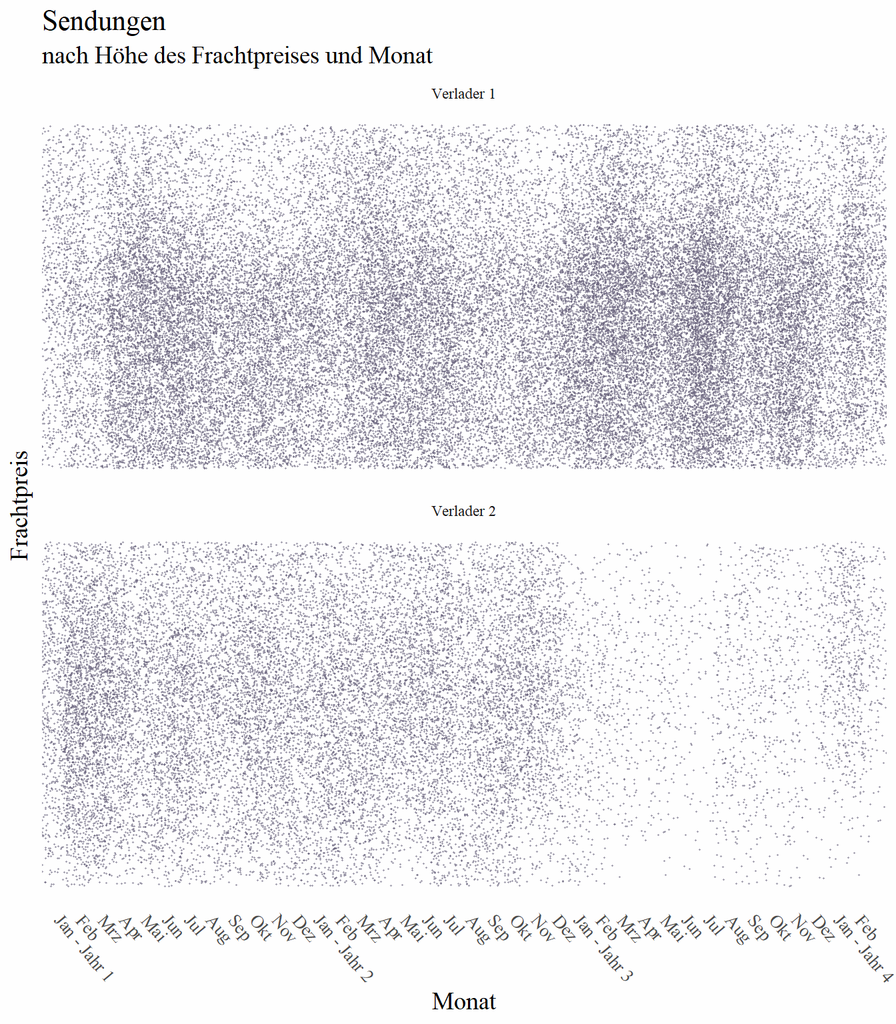

Es wird klar, dass Verlader 1 die größeren Mengen bewegt. Wobei seine Frachtpreise mehrheitlich im niedrigen und mittleren Bereich liegen. Verlader 2 hat ca. gleich viele Sendungen im jeweils niedrigen, mittleren und hohen Bereich. Nach massivem Rückgang des Sendungsaufkommen bei Verlader 2 (ab Januar Jahr 3), stiegen dort auch die Frachtpreise - sehr deutlich über die letzten beiden Monate erkennbar. Allerdings zog bei Verlader 2 auch das Sendungsaufkommen über die letzten beiden Monate wieder an. Generell sind bei Verlader 2 keine saisonalen Spitzen im Sendungsaufkommen sichtbar. Bei Verlader 1 hingegen schon - erkennbar an den Wellenmustern.

## Vergleich

Um zu sehen, auf welchen Routen eine Zusammenarbeit Sinn macht, ordne ich die *Sendungspunkte* den einzelnen Destinationen (0-9) zu. Um den direkten Vergleich zwischen den Verladern zu ermöglichen, lege ich deren Sendungen grafisch übereinander. Pro Route entsteht so ein *Bild*. Großes Kooperationspotential wird sichtbar durch hohe Sendungsdichte (viele Punkte) bei gleich hoher Sendungsanzahl pro Verlader (orange/blau durchmischt).

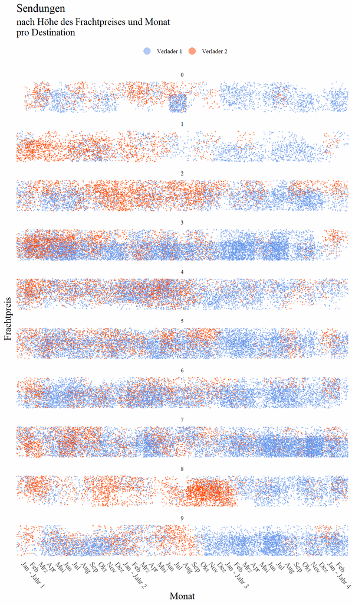